# Modulo 2 parte 1 - TECNICHE DI KRIGING GEOSTATISTICA LIVELLO BASE

Francesco Pirotti

2024-09-13

# Riferimenti utili

CRS - coordinate reference system  
https://r.geocompx.org/spatial-class#crs-intro  
https://r-spatial.org/book/02-Spaces.html#sec-crs  
meuse dataset  
https://cloud.r-project.org/web/packages/gstat/vignettes/gstat.pdf  
metodi di interpolazione geografica  
https://r-spatial.org/book/12-Interpolation.html

# Basi teoriche

Proprietà specifiche delle misure geostatistiche di **variabilità spaziale**. Cosa si intende per variabilità spaziale? Cosa vogliamo studiare?

Vogliamo un modello per “spiegare” la variabilità e dunque poter stimare (interpolare) al meglio dove non abbiamo informazioni.

Stimare valori di una variabile applicando un modello creato conoscendo valori misurati (e.g. campionamenti). E’ ragionevole adottare un criterio spaziale, ovvero usare un criterio di spazio (il valore del punto sarà probabilmente più simile ad una misura vicina che una misura più lontana, **a parità di altre condizioni)**. Da qui la geostatistica.

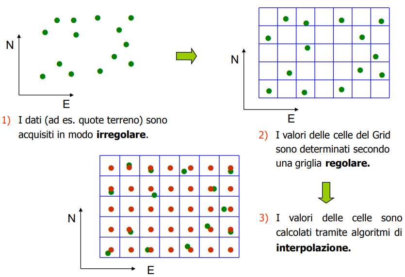

fonte: Appunti GIS Prof. Alberto Guarnieri

# Dati di esempio

VEDI anche https://www.cirgeo.unipd.it/app01/GeospatialApp/

E’ possibile costruire un modello di regressione utilizzando le coordinate dei dati come covariate per descrivere la variazione spaziale della variabile di interesse. In molti casi, per descrivere adeguatamente l’effetto della posizione sarà necessaria una funzione **non** lineare basata sulle coordinate.

In questo esempio usiamo due transetti: t1=nero, t2=rosso estratti dalla della mappa di temperatura media della superficie del suolo del 2017 estratta da sensore MODIS*. Carichiamo i valori di temperatura dei due transetti:

```r
suppressMessages(library(terra))
load("esercizi/modulo2/data/modulo2.rda")
modisTemp <- terra::rast("esercizi/modulo2/data/VenetoCorrectedMODIS_LST_Avg2017.tif")
```

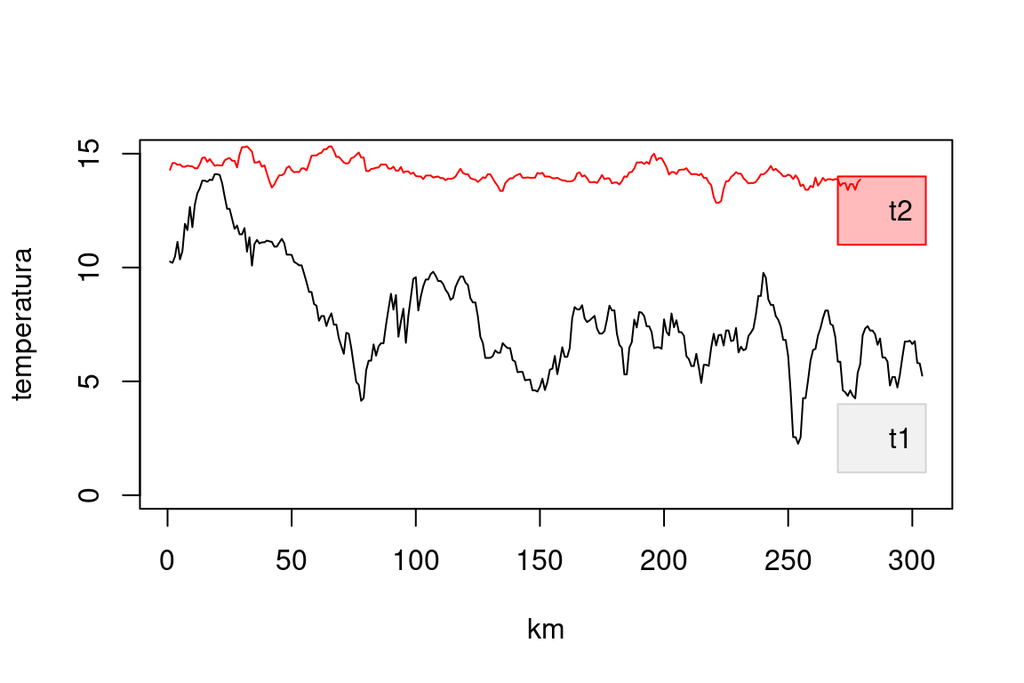

```r
plot(modisTemp)
plot(t1, type="l", xlab="km", ylab="temperatura", ylim=c(0,15))
lines(t2, col="red" )
legend(270, 4, "t1", box.col = "lightgrey", bg = "#cccccc44" )
legend(270, 14, "t2", box.col = "red", bg = "#ff000044" )
```

*Il sensore MODIS non misura la temperatura dell’aria ma l’emissione di calore delle superfici. Questa mappa è stata estratta con un fattore di correzione molto generico per renderla più simile alla temperatura dell’aria. Vedi esercizio 01 per replicare l’estrazione.

# Varianza

Vediamo come valutare alcuni momenti di una distribuzione - media e varianza ci danno il primo e secondo momento. Z è la variabile aleatoria, nel nostro caso la temperatura.

$$M(Z)=\mu_Z=\mathbb E[Z]$$

$$M(Z)=\mu_Z=\frac{1}{n}\sum_{j=1}^n{Z_j}$$

$$Var(Z)=\sigma^2_Z=\mathbb{E}\Big[\big(Z-\mathbb{E}[Z]\big)^2\Big].$$

$$Var(Z)=\sigma^2_Z=\frac{\sum_{j=1}^n(Z_j-M_Z)^2}{n}$$

Formula più pratica

$$Var(Z)=\sigma^2_Z=\mathbb{E}[Z^2]-\mathbb{E}[Z]^2$$

$$Var(Z)=\sigma^2_Z=M(Z^2)-M(Z)^2$$

# Varianza esempio

Calcoliamo la varianza con tre formule diverse:

```r
MX<-mean(t2)
VarX <- var(t2)
MX2<-mean(t2^2)
VarX2 <- MX2 - MX^2
VarX3 <- mean((t2-MX)^2)

paste("Media:", round(MX,3), " Varianza f1:", round(VarX,4),
      " Varianzaf2:", round(VarX2,4), " Varianzaf3:", round(VarX3,4) )
```

```
## [1] "Media: 14.17  Varianza f1: 0.1971  Varianzaf2: 0.1964  Varianzaf3: 0.1964"
```

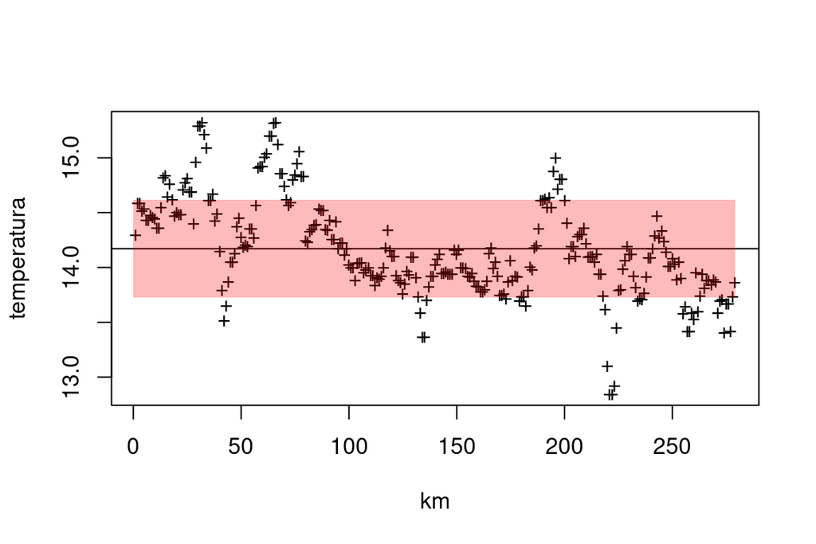

```r
plot(t2, xlab="km", ylab="temperatura", pch="+")
abline(a = MX,0 )
rect(0, MX-VarX^0.5, length(t2),
     MX+VarX^0.5, col = "#ff000045", border = "#ffffff00")
```

```r
# varianza  = (dev std)^2
```

# Varianza esempio (2)

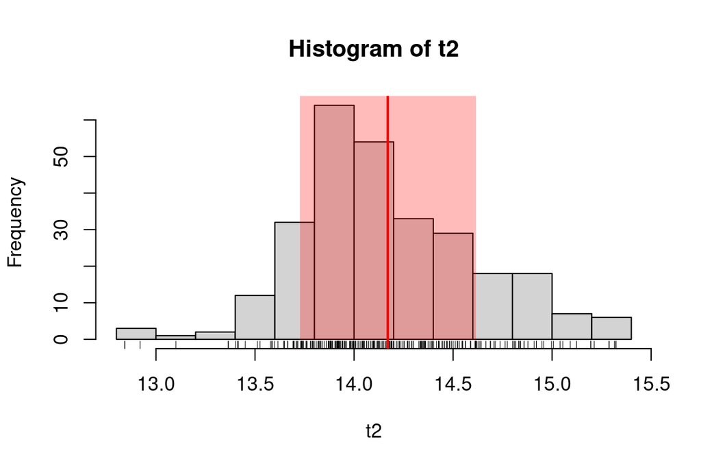

```r
hist(t2)
rug(t2)
rect(MX-VarX^0.5, 10000,
     MX+VarX^0.5, 0, col = "#ff000045", border = "#ffffff00")
abline(v=MX, col="red", lwd=2)
```

# Covarianza

Tra due variabili, Z1 e Z2, come dice il nome stesso, se e quanto “variano insieme nella stessa direzione” (NB lineare e dello stesso segno).

$$\mathrm{Cov}(Z1,Z2)=\mathbb{E}\Big[\big(Z1-\mathbb{E}[Z1]\big)(Z2-\mathbb{E}[Z2]\big)\Big]$$

```r
CovX<-cov(t2, t2)
CovX
```

```
## [1] 0.1970752
```

```r
VarX
```

```
## [1] 0.1970752
```

# Covarianza (2)

MA se misuriamo come “Co-varia” con la misura subito dopo lungo il transetto? Ovvero “trasliamo” di uno lungo X e correliamo con il dato originale…

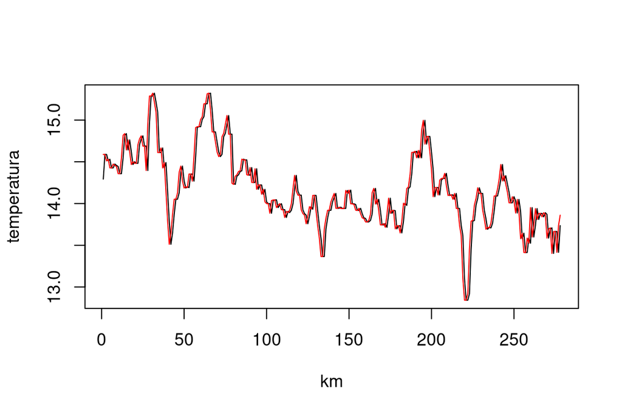

```r
nm <- length(t2)
plot(t2[1:(nm-1)], type="l", xlab="km", ylab="temperatura")
lines(t2[2:nm], col="red" )
```

```r
cov(t2[1:(nm-1)], t2[2:nm] )
```

```
## [1] 0.1852625
```

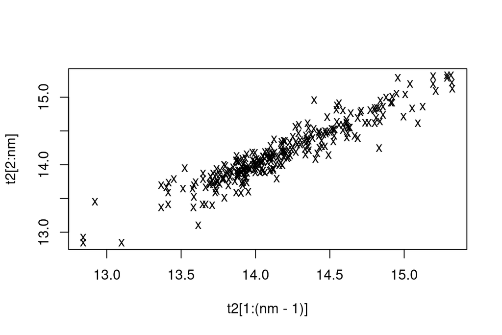

```r
plot(t2[1:(nm-1)], t2[2:nm], pch="x" )
```

# Covarianza (3)

Più aumentiamo la distanza del lag, come è ragionevole pensare per dati spazialmente correlati, più diminuisce il valore di covarianza (si allontana dal valore della varianza == covarianza ).

Se si abbassa per poi rialzarsi, può indicare un pattern ricorrente (provate sostituendo i valori di t2 con un valore ciclico come `t2 <- sin((1:200)/10)` .

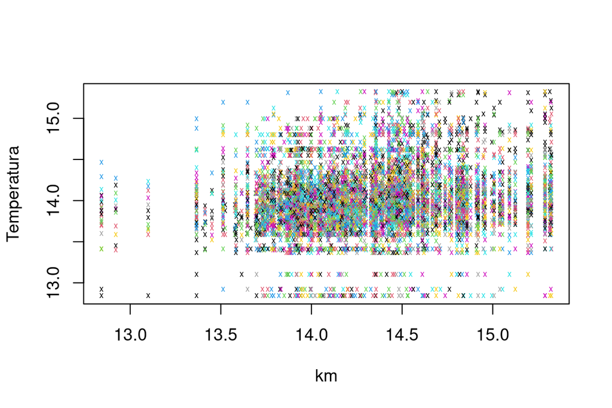

```r
plot(t2[1:(nm-1)], t2[2:nm], pch="x", cex=0.5, xlab="km", ylab="Temperatura" )
cc=1
covs<-list("0"=CovX, "1"=cov(t2[1:(nm-1)], t2[2:nm] ) )

for(lag in seq(6, nm, 5)){
  covs[[as.character(lag)]]<-cov(t2[1:(nm-lag)], t2[(lag+1):nm])
  points(t2[1:(nm-lag)], t2[(lag+1):nm], pch="x",cex=0.5, col=cc )
  cc=cc+1
}
```

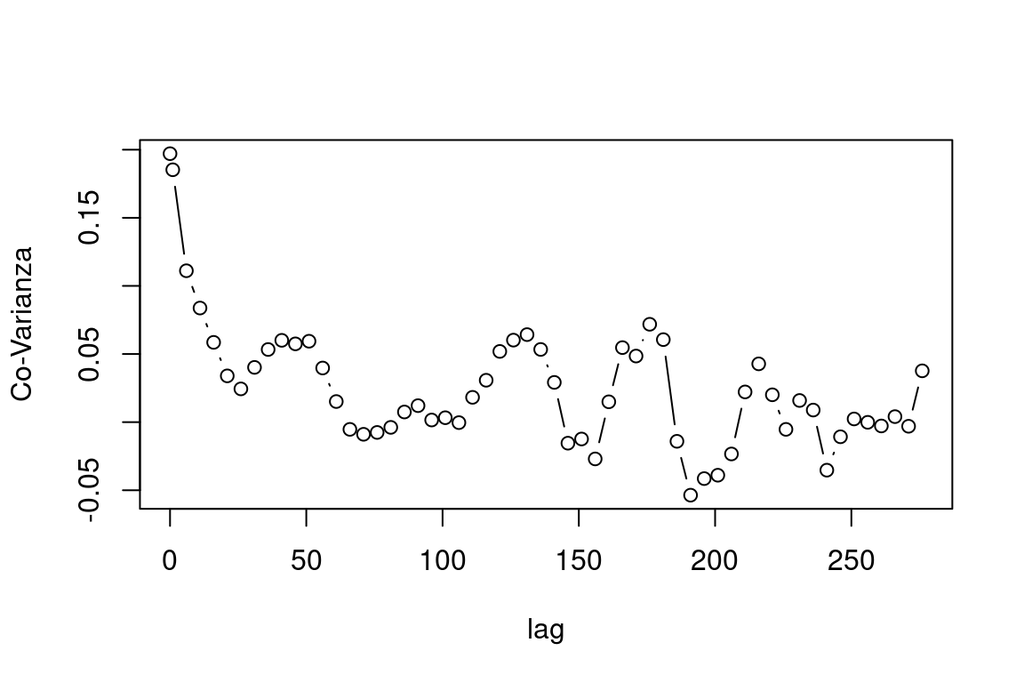

```r
plot(names(covs),  unlist(covs), type="b",
     ylab="Co-Varianza",
     xlab="lag" )
```

# Covarianza (4)

Non ci crediamo? Rifacciamolo per un dato casuale con media e varianza uguale a quella del nostro dato:

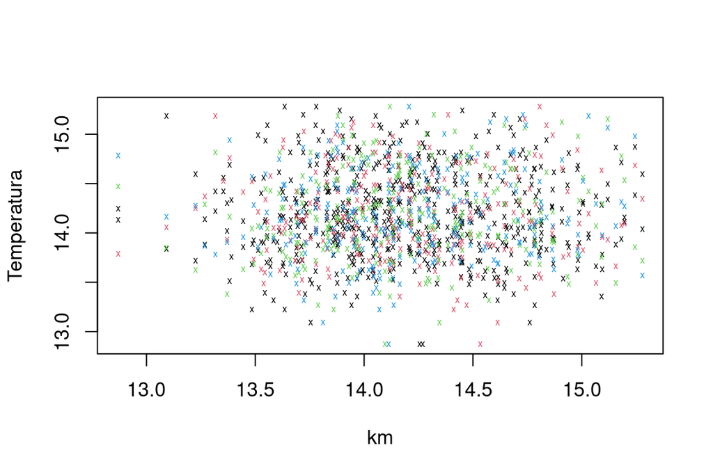

```r
t.rand <- rnorm(nm, mean = MX, sd = VarX^0.5)

plot(t.rand[1:(nm-1)], t.rand[2:nm], pch="x", cex=0.5, xlab="km", ylab="Temperatura" )
cc=1
covs.rand<-list("0"=cov(t.rand, t.rand), "1"=cov(t.rand[1:(nm-1)], t.rand[2:nm] ) )

for(lag in seq(6, 36, 10)){
  covs.rand[[as.character(lag)]] <- cov(t.rand[1:(nm-lag)], t.rand[(lag+1):nm])
  points(t.rand[1:(nm-lag)], t.rand[(lag+1):nm], cex=0.5, pch="x", col=cc )
  cc=cc+1
}
```

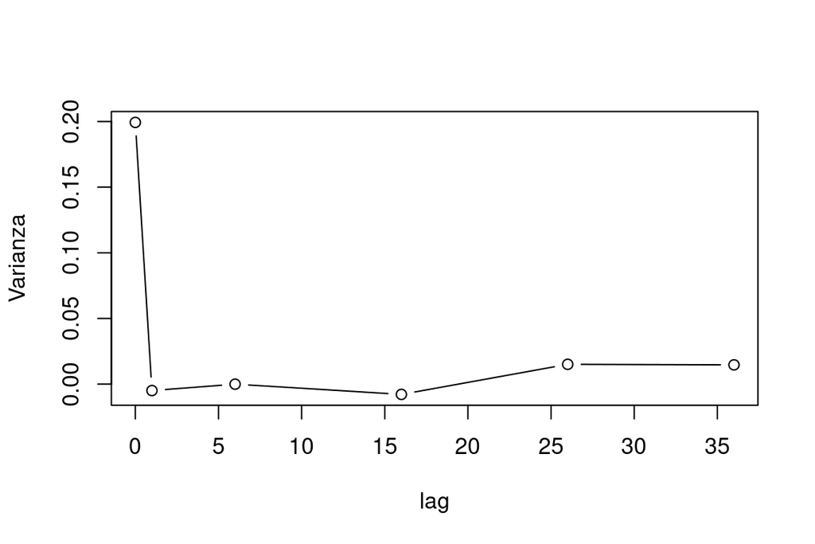

```r
plot(names(covs.rand),  unlist(covs.rand), type="b",
     ylab="Varianza",
     xlab="lag" )
```

# Correlazione

Relazione lineare tra due variabili, cosiddetta di Pearson. Semplicemente normalizza per le deviazioni standard:

$$-1\le\rho_{Z1Z2}=\frac{Cov(Z1Z2)}{\sqrt{Var(Z1)}\cdot\sqrt{Var(Z2)}}=\frac{\sum_{i=1}^n(Z1-{\mu_{Z1}})(Z2-{\mu_{Z2}})}{\sqrt{\sum_{i=1}^n(y_i-{\mu_{Z1}})^2}\sqrt{\sum_{i=1}^n(y_i-{\mu_{Z2}})^2}}\le+1$$

# Autocorrelazione

Come indicato anche nelle slide della Covarianza (Covarianza (3) e Covarianza (4)), indica quanto una variabile è correlata a se stessa data una modifica nel dominio dei valori. In una dimensione, che sia tempo o spazio come nel nostro transetto, si dice anche “lag” che può essere tradotto come “sfasamento” delle linee nel dominio spaziale o temporale. Viene analizzato con la funzione CCF :

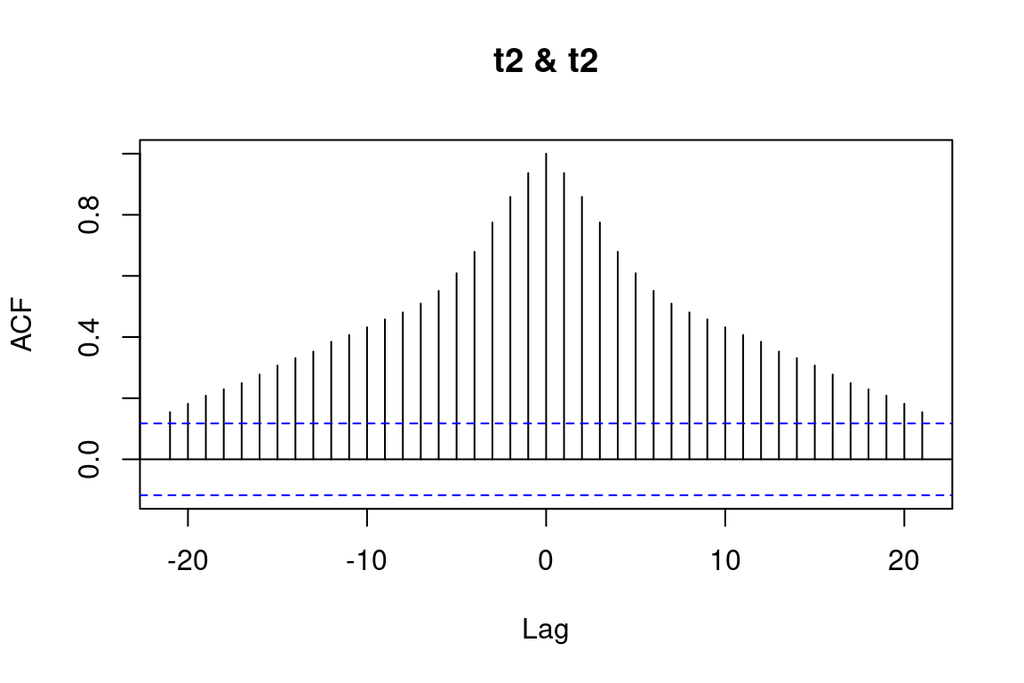

```r
  #ccf(t2, t2, plot = F)
  ccf(t2, t2)
```

# Fondamenti di algebra lineare nella regressione lineare

Perchè iniziamo con la regressione lineare? Perchè molti fenomeni sono affetti da “trend” o tendenze di segno positivo o negativo. Ovvero all’aumentare di X la variabile Z aumenta o diminuisce (correlazione positiva o negativa). Vediamo i nostri 2 plot dei 2 transetti…

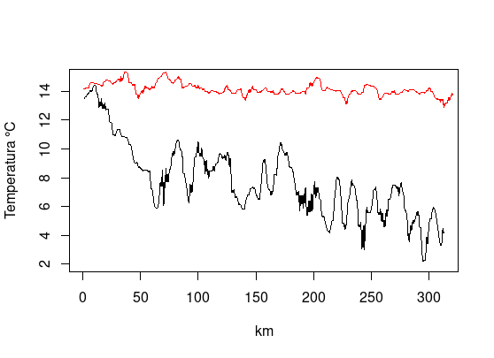

# Fondamenti di algebra lineare nella regressione lineare (2)

E’ chiaro che ci sia un trend molto marcato nel transetto 1 (linea nera)… è dato dalla evidente correlazione tra temperatura e quota, muovendoci verso nord direttamente si intercettano le Alpi. Nota che ci possono essere trend diversi a seconda della finestra considerata nel dominio X. Come facciamo a capirlo?

# Fondamenti di algebra lineare nella regressione lineare (3)

Un metodo noto è il metodo dei minimi quadrati per stimare un modello lineare che “spiega” al meglio i valori osservati minimizzando gli errori espressi in valore assoluto o come quadrato degli scarti sotto illustrato*

$$Z_i = \beta_0 + \beta_1 X_i +
u_i$$

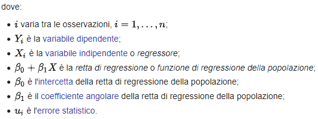

*fonte: [wikipedia](https://it.wikipedia.org/wiki/Regressione_lineare)

# Fondamenti di algebra lineare nella regressione lineare (4)

Modelli lineari, nei pacchetti di base, (lm) emodelli lineari robusti, nel pacchetto MASS (rlm). Questi hanno un:

- lato sinistro: variabile/i (matematicamente) dipendente/i
- Operatore di formula ~, letto come “dipende da”, “è funzione di”.
- lato destro: variabile (matematicamente) indipendente (o variabili)

```r
dati<- data.frame(Temperatura=t2, Distanza_Km=1:length(t2) )
# modello.lm <- lm(data = dati)
modello.lm <- lm(Temperatura~Distanza_Km, data = dati)
#summary(modello.lm)
# per riportare i parametri del modello meglio usare sjPlot ----
sjPlot::tab_model(modello.lm)
```

|  | Temperatura |  |  |
| --- | --- | --- | --- |
| Predictors | Estimates | CI | p |
| (Intercept) | 14.62 | 14.53 – 14.70 | **<0.001** |
| Distanza Km | -0.00 | -0.00 – -0.00 | **<0.001** |
| Observations | 279 |  |  |
| R<sup>2</sup> / R<sup>2</sup> adjusted | 0.338 / 0.335 |  |  |

# Fondamenti di algebra lineare nella regressione lineare (5)

Modelli: Il lato destro può avere operatori che sembrano aritmetici ma sono interpretati in termini di struttura del modello:

- `+` effetto additivo
- `*` effetto di interazione
- `/` modello annidato
- `-` rimuovere i termini dal modello

Per le formule aritmetiche all’interno del modello, è necessario utilizzare la funzione I “identità”.

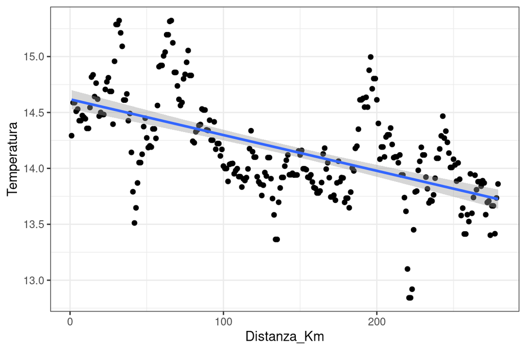

```r
ggplot(dati, aes(x = Distanza_Km, y = Temperatura)) +
  geom_point() +
  stat_smooth(method = "lm") + theme_bw()
```

# Let’s go SPATIAL

Invece del transetto campioniamo dei punti di temperatura e quota. Vedi Esercizio 3 del Modulo 2 “modulo2_es03_goSpatial.R”.

Per illustrare l’uso degli operatori e delle identità, proviamo modelli di temperatura funzione di varie potenze della quota e vediamo quello più performante.

```r
## leggiamo la quota
temp <- terra::rast("GeospatialApp/data/VenetoCorrectedMODIS_LST_Avg2017.tif")
## aggiungiamo una potenziale covariata - la quota!
DEM <- terra::rast("GeospatialApp/data/VenetoDEM.tif")
smpl <- terra::spatSample(temp, method="random",
                        size=2000, na.rm=T, xy=T ) #as.points=T
## NB quota in km! poi vediamo perchè
smpl$altitude <- terra::extract(DEM, smpl[,1:2], ID=F )[[1]]/1000
smpl$altitudeM <- terra::extract(DEM, smpl[,1:2], ID=F )[[1]]
names(smpl)
```

```
## [1] "x"         "y"         "mean"      "altitude"  "altitudeM"
```

```r
names(smpl)<-c("x","y","Temp", "Quota.km", "Quota.m")
smpl<-as_tibble(smpl)
```

# Regressioni tra covariate

```r
modello.lm <- lm(Temp~`Quota.km`, data = smpl)
sjPlot::tab_model(modello.lm)
```

|  | Temp |  |  |
| --- | --- | --- | --- |
| Predictors | Estimates | CI | p |
| (Intercept) | 13.81 | 13.73 – 13.89 | **<0.001** |
| Quota km | -5.21 | -5.29 – -5.14 | **<0.001** |
| Observations | 1984 |  |  |
| R<sup>2</sup> / R<sup>2</sup> adjusted | 0.904 / 0.904 |  |  |

```r
modello.lm <- lm(Temp~`Quota.m`, data = smpl)
sjPlot::tab_model(modello.lm)
```

|  | Temp |  |  |
| --- | --- | --- | --- |
| Predictors | Estimates | CI | p |
| (Intercept) | 13.81 | 13.73 – 13.89 | **<0.001** |
| Quota m | -0.01 | -0.01 – -0.01 | **<0.001** |
| Observations | 1984 |  |  |
| R<sup>2</sup> / R<sup>2</sup> adjusted | 0.904 / 0.904 |  |  |

```r
modello.lm <- lm(Temp~I(`Quota.km`^0.5), data = smpl)
sjPlot::tab_model(modello.lm)
```

|  | Temp |  |  |
| --- | --- | --- | --- |
| Predictors | Estimates | CI | p |
| (Intercept) | 15.38 | 15.28 – 15.48 | **<0.001** |
| Quota km^0 5 | -7.86 | -7.97 – -7.75 | **<0.001** |
| Observations | 1873 |  |  |
| R<sup>2</sup> / R<sup>2</sup> adjusted | 0.908 / 0.907 |  |  |

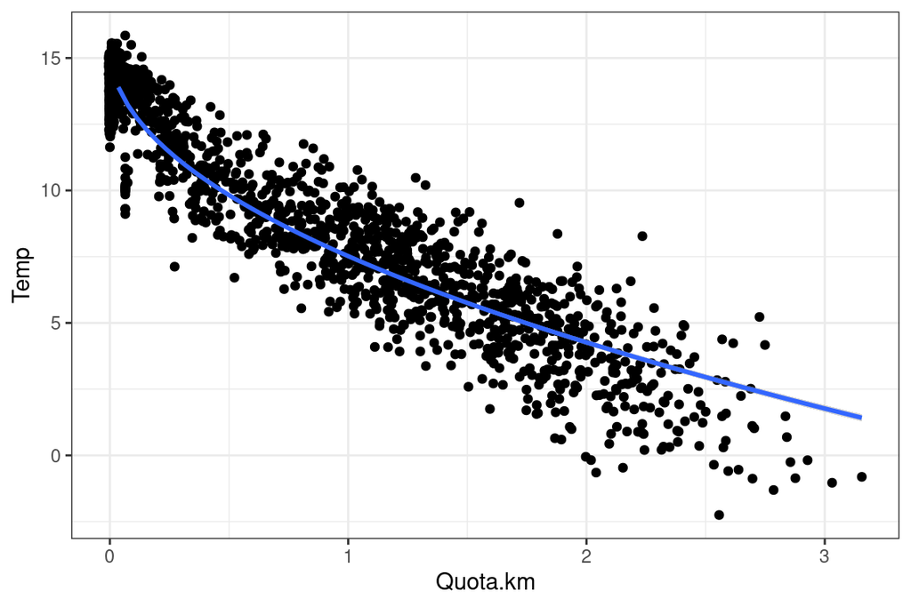

```r
ggplot(smpl, aes(x = `Quota.km`, y = Temp)) +
  geom_point() +
  stat_smooth(data=smpl, method = "lm", formula = y~I(x^0.5) )  + theme_bw()
```

# Stazionarietà e isotropia

L’interpolazione con kriging si basa su alcune assunzioni fondamentali riguardo alla natura dei dati spaziali. Tra queste, le più importanti sono la stazionarietà e l’isotropia.

I due presupposti principali affinché il kriging fornisca la migliore previsione lineare imparziale sono quelli della stazionarietà e dell’isotropia, sebbene esistano varie forme e metodi di kriging che consentono di allentare la forma più rigorosa di ciascuno di questi presupposti. Tuttavia, nella realtà, queste condizioni sono spesso violate, rendendo necessario adottare approcci più flessibili.

# Stazionarietà e isotropia

1. Stazionarietà “formale”: le proprietà statistiche del processo spaziale rimangono costanti **in tutte le località**. La distribuzione di probabilità congiunta non varia nello spazio di studio. Di conseguenza, i parametri (come la media complessiva dei valori, l’intervallo e la soglia del variogramma*) non variano nello spazio di studio. Si presume che lo stesso modello di variogramma* sia valido in tutto lo spazio di studio. Si tratta di un’ipotesi che raramente si verifica nei dati del mondo reale.
2. Stazionarietà “debole”: si ipotizza che la media e la varianza/covarianza siano costanti nella regione di interesse

* Spoiler: il variogramma è un grafico con l’asse delle x che rappresenta la distanza tra due punti e l’asse delle y che rappresenta la varianza delle differenze tra i valori misurati in quei due punti. Solitamente si usa il SEMIvariogramma, ovvero la semivarianza, i.e. metà della media di tutte le differenze tra valori di punti che si trovano entro una certa distanza reciproca.

# Stazionarietà e isotropia

# Stazionarietà

La caratteristica di stazionarietà è fondamentale per molte tecniche geostatistiche

Stazionarietà di primo ordine: stazionarietà della media, ovvero un campione in due aree diverse della regione di studio hanno media uguale.

Stazionarietà di secondo ordine: stazionarietà della varianza, ovvero un campione in due aree diverse della regione di studio hanno varianza uguale.

Quasi sempre rappresenta una semplificazione della realtà.

La dimostrazione della stazionarietà in pratica è complesso per le seguenti ragioni:

1. **Dati limitati:** I dati geostatistici sono tipicamente sparsi e irregolarmente distribuiti, rendendo difficile valutare le proprietà statistiche sull’intera area di studio.
2. **Eterogeneità spaziale:** La maggior parte dei fenomeni naturali presenta una certa variabilità spaziale.
3. **Dipendenza dalla scala:** I pattern spaziali possono cambiare con la scala, complicando la valutazione della stazionarietà.

Siccome abbiamo simulato un dataset completo, vediamo effettivamente la difficoltà nel soddisfare queste condizioni:

# Stazionarietà: Approcci pratici

Metodi per valutare il grado di stazionarietà:

- **Analisi esplorativa dei dati (EDA):**
  - Visualizzare i dati utilizzando istogrammi, scatter plot e mappe per identificare potenziali trend o pattern.
  - Calcolare statistiche descrittive (media, varianza) per diversi sottoinsiemi dei dati per verificare la consistenza.
- **Analisi del variogramma:**
  - Esaminare il variogramma per evidenziare la stazionarietà (ad esempio, raggiungimento di un plateau, comportamento isotropo).
  - Considerare l’adattamento di diversi modelli di variogramma per valutare la loro aderenza.

# Stazionarietà: Considerazioni importanti

- **La stazionarietà è spesso un’approssimazione:** In pratica, spesso si assume una stazionarietà approssimativa per applicare i metodi geostatistici.
- **Stazionarietà locale:** Può essere ragionevole assumere la stazionarietà all’interno di sottoregioni più piccole.
- **Metodi non stazionari:** Se la stazionarietà è chiaramente violata, considerare l’utilizzo di metodi geostatistici non stazionari o altre tecniche di analisi spaziale.

**Ricorda:** L’obiettivo non è dimostrare la stazionarietà senza ombra di dubbio, ma valutare la sua plausibilità e prendere decisioni informate sull’adeguatezza dei metodi geostatistici

# Stazionarietà: esercizio

Testiamo sul transetto n. 2 (T2 ovvero quello rosso).

Poi provato con T1, quali dei due processi è “più stazionario”?

Esercizio 2 del Modulo 2

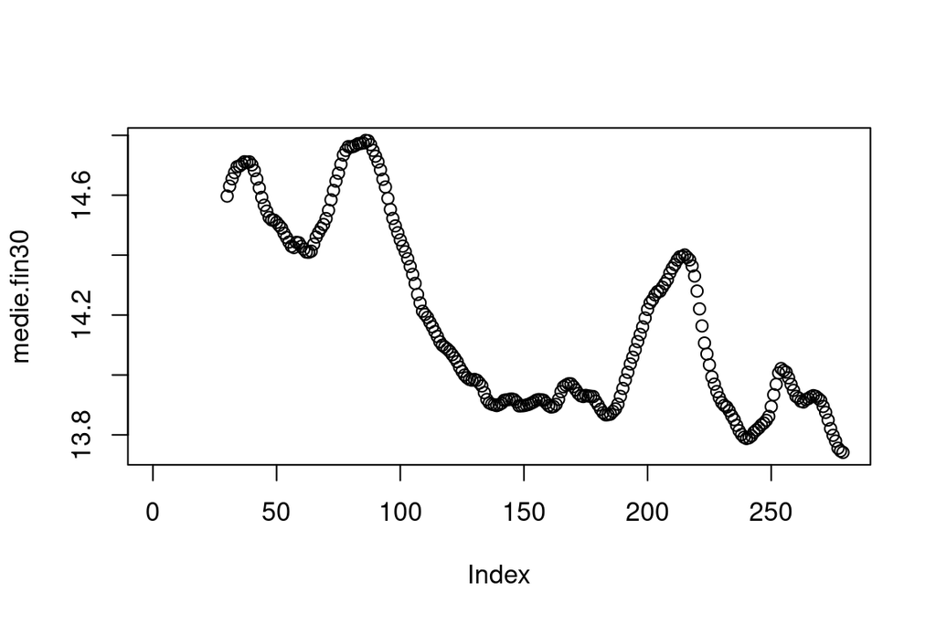

```r
varianze.fin30 <- rollapplyr(t2, 30, var, by.column = FALSE, fill = NA)
medie.fin30 <- rollapplyr(t2, 30, mean, by.column = FALSE, fill = NA)

plot(medie.fin30)
```

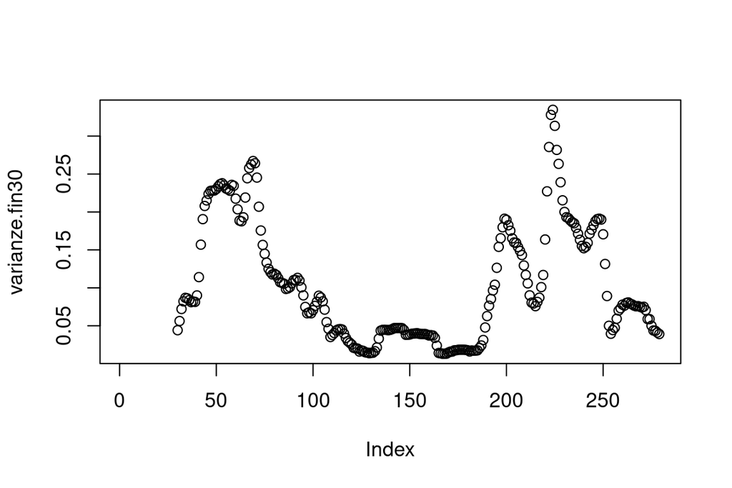

```r
plot(varianze.fin30)
```

# Test di stazionarietà - variogramma

Insomma… i miei dati 2D soddisfano il presupposto di stazionarietà o no? O almeno quanto sono lontani da una perfetta stazionarietà?

NB - La stazionarietà è una decisione, non un’ipotesi (cit. M. Pyrcz); pertanto non può essere testata. I dati possono dimostrare che non è una supposizione appropriata.

La valutazione della stazionarietà dipende dalla scala. La scelta della scala deve basarsi sul problema specifico.

Per indagare/valutare la stazionarietà dei dati spaziali, in pratica la cosa migliore è usare un **variogramma o un autocorrelogramma**: - nel primo caso è un grafico che mostra come cambia il valore la covarianza a diversi lag.

# Variogramma

Immagina di avere una mappa che mostra il valore di una variabile (e.g. temperatura). I valori varieranno da punto a punto, e questa variabilità non è casuale: punti vicini tendono ad avere valori più simili rispetto a punti lontani. Il variogramma è uno strumento grafico che permette di visualizzare e quantificare questa relazione tra la distanza e la variabilità di un fenomeno spaziale.

Per ogni coppia di punti a una determinata distanza, si calcola la metà della differenza al quadrato dei loro valori. Questa quantità è chiamata **semivarianza**. Il variogramma mette nell’asse X la distanza e nell’asse Y la semivarianza.

Elementi:

- **Nugget:** Il valore iniziale del variogramma, indica la variabilità a brevissima distanza. Un nugget elevato suggerisce una componente casuale significativa.
- **Sill:** Il valore massimo a cui tende il variogramma, rappresenta la variabilità totale.
- **Portata:** La distanza alla quale il variogramma raggiunge il sill, indica la distanza oltre la quale i valori sono considerati indipendenti.

Il variogramma si dice delimitato se raggiunge un massimo tetto (sill) di varianza e si può decidere che i dati sono stazionari, ma se il variogramma non è delimitato (non raggiunge un massimo) no.

# Semivariogramma - cloud vs. plot

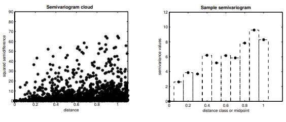

Fonte: Dr. Gaufeng Cao - University of Colorado Boulder

# Semivariogramma - esempi 1

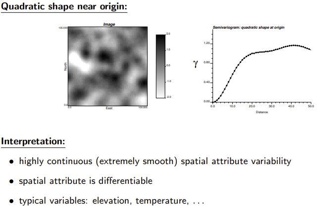

Fonte: Dr. Gaufeng Cao - University of Colorado Boulder

# Semivariogramma - esempi 2

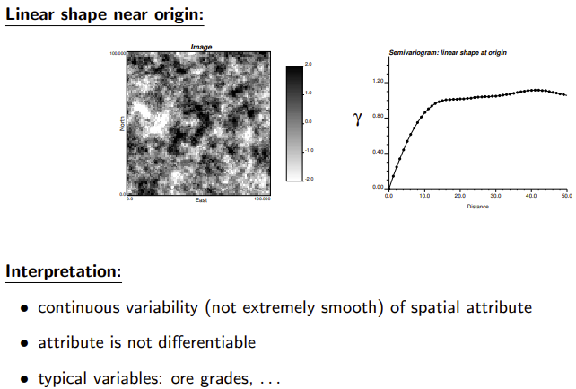

Fonte: Dr. Gaufeng Cao - University of Colorado Boulder

# Semivariogramma - esempi 3

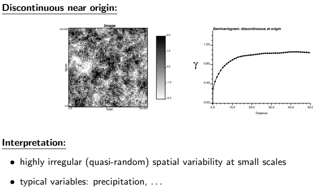

Fonte: Dr. Gaufeng Cao - University of Colorado Boulder

# Semivariogramma - esempi 4

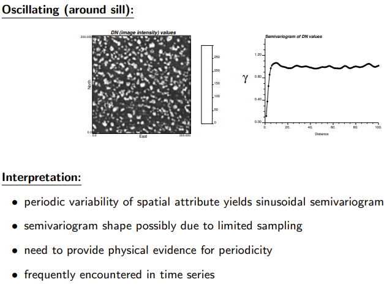

Fonte: Dr. Gaufeng Cao - University of Colorado Boulder

# Semivariogramma - test

Proviamo con il nostro transetto…

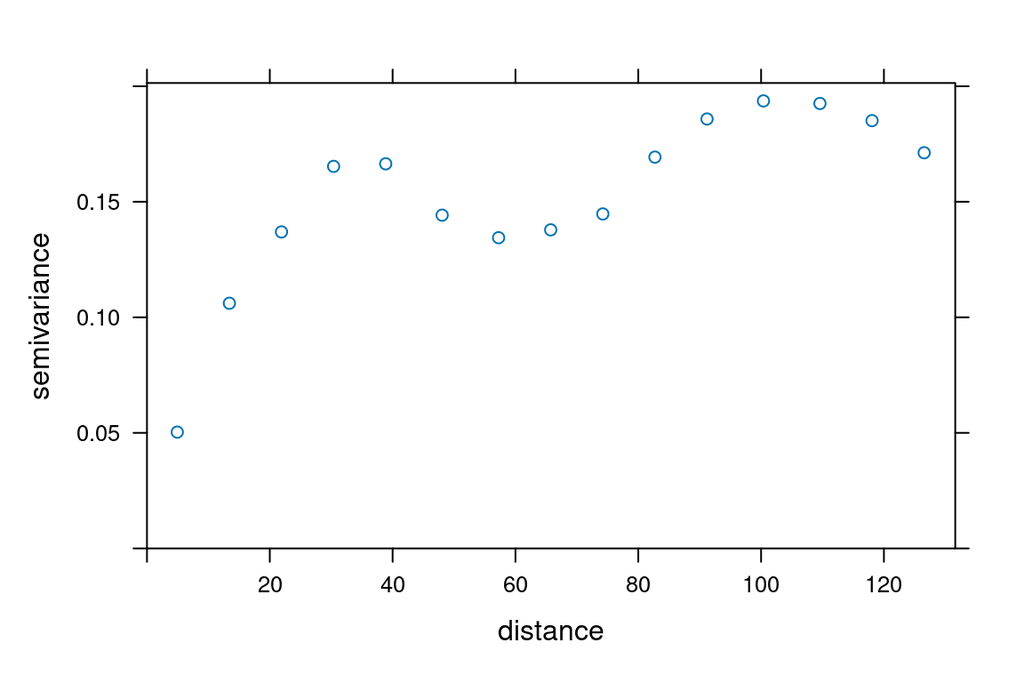

```r
dati = data.frame(Temperatura=t2)
dati$X=1:nrow(dati)
dati$Y=1:nrow(dati)
coordinates(dati)<-  ~X+Y

vr=gstat::variogram(Temperatura~1, data=dati)
plot(vr)
```

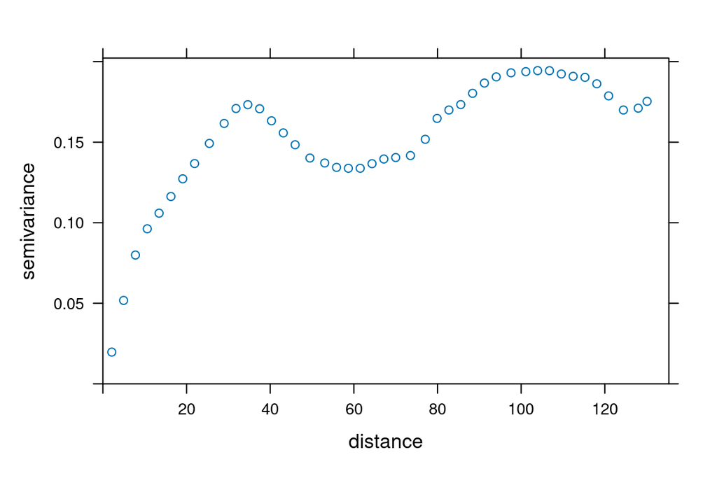

```r
vr=gstat::variogram(Temperatura~1, data=dati, width=3)
plot(vr)
```

[figure not shown]

```r
vr=gstat::variogram(Temperatura~1, data=dati,alpha=90, width=3)
plot(vr)
```

# Autocorrelogramma

nel secondo caso è un grafico che mostra l’autocorrelazione dei valori dei dati a diversi lag (spaziali o temporali).

Si vuole studiare l’associazione tra le osservazioni della variabile analizzata in funzione di distanza e direzione. Le funzioni di covarianza, il correlogramma e il variogramma / il semivariogramma sono tutte funzioni che caratterizzano numericamente la forza di tali associazioni.

# Stazionarietà - variogramma

**Forma coerente:** La forma complessiva del variogramma (ad esempio, sferica, esponenziale) deve rimanere coerente in diverse parti dell’area di studio.

**Nessuna tendenza sistematica:** Il variogramma non deve presentare tendenze chiare verso l’alto o verso il basso all’aumentare della distanza.

**Nessuna dipendenza dalla posizione:** Il variogramma non deve variare in modo significativo a seconda della posizione delle coppie di punti all’interno dell’area di studio.

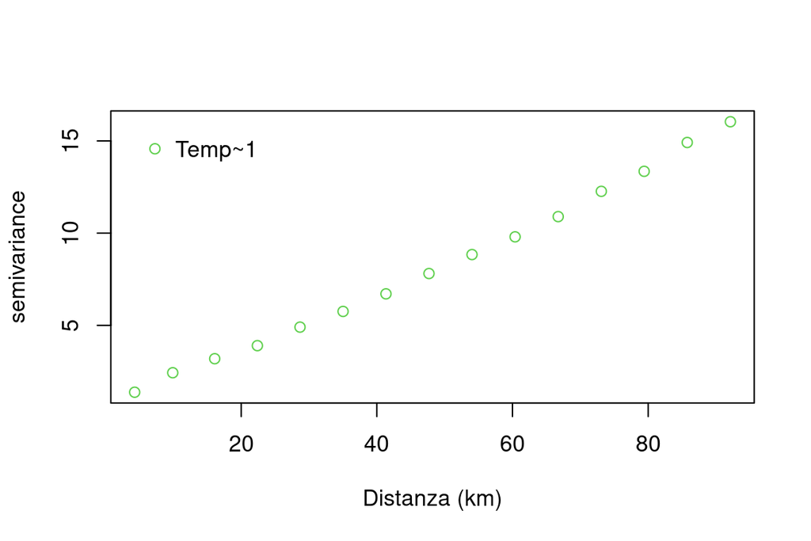

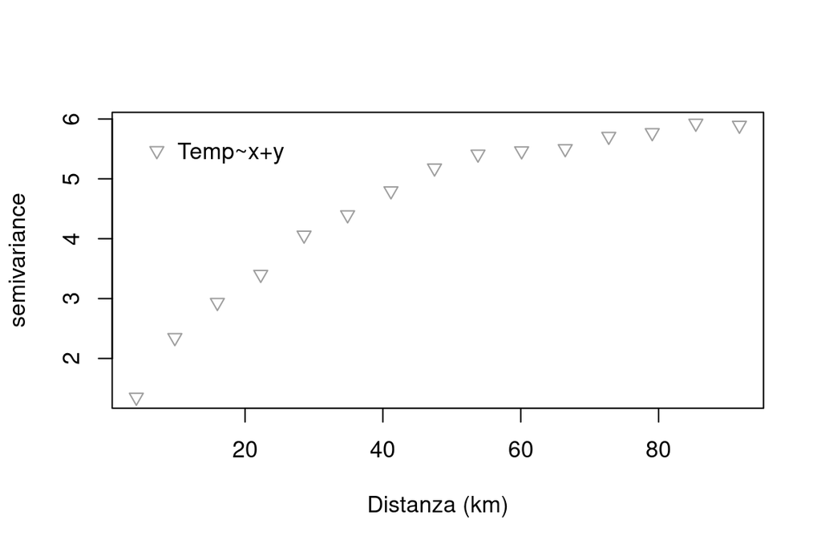

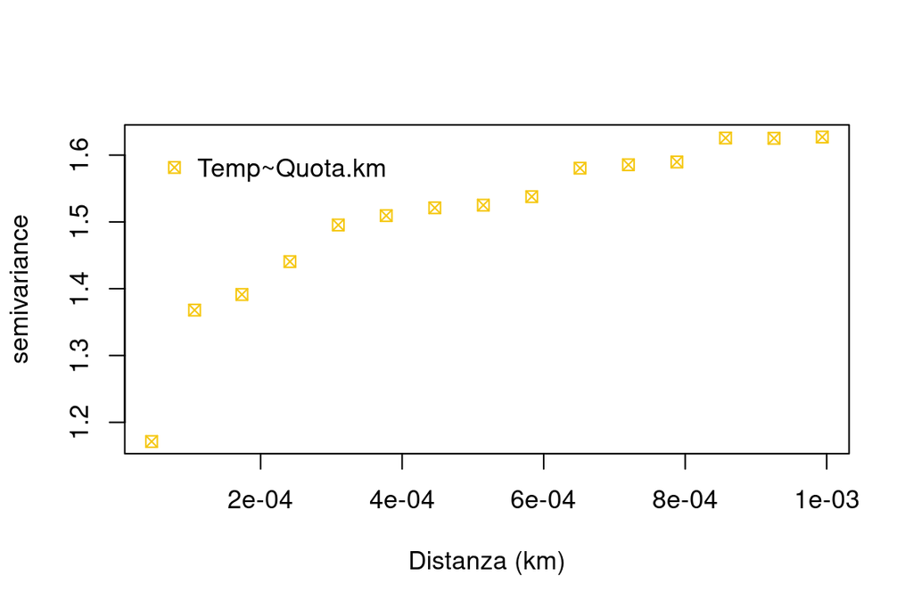

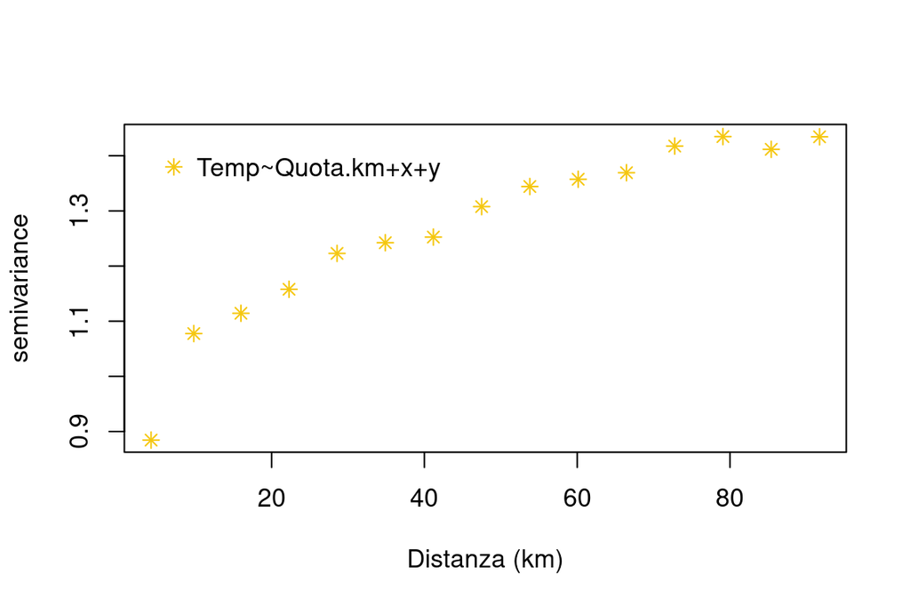

```r
library(gstat)

myplots<-function(vrs){
  add=F
  for(name in names(vrs)){
    vr <- vrs[[name]]
      col=runif(1,min=1,max=10)
  pch=runif(1,min=1,max=10)
  if(!add) {
    plot(vr$dist/1000, vr$gamma, xlab="Distanza (km)", ylab="semivariance",col=col,
       pch=pch)
  }
  else {
    points(vr$dist, vr$gamma,col=col,
       pch=pch)

  }
  legend(min(vr$dist/1000), max(vr$gamma),bty = "n", name, col=col,  pch=pch  )
  }
 add=T
}

## trasformiamo da terra vect a oggetto sf, poi
## lo proiettiamo su un sistema cartografico
## https://epsg.io/3035
## per avere le distanze in metri
smpl.spat <- smpl %>% sf::st_as_sf(coords = c("x","y"), crs=4326) %>%
                      sf::st_transform(3035)
plots  <- list()
plots[["Temp~1"]]  <- gstat::variogram(Temp~1, smpl.spat)

smpl.spat$x<- sf::st_coordinates(smpl.spat)[,1]
smpl.spat$y<- sf::st_coordinates(smpl.spat)[,2]

## decisione di stazionarietà migliorata, variagramma con sill.
plots[["Temp~x+y"]] <-  gstat::variogram(Temp~x+y, na.omit(smpl.spat))


plots[["Temp~Quota.km"]] <- gstat::variogram(Temp~Quota.km, data=as.data.frame(na.omit(smpl)), locations = ~x+y  )

plots[["Temp~Quota.km+x+y"]] <- gstat::variogram(Temp~Quota.km+x+y, na.omit(smpl.spat))

myplots(plots)
```

# Test di stazionarietà - variogramma (3)

Vedi portale interattivo [Geospatial App](https://www.cirgeo.unipd.it/app01/GeospatialApp/)

# Isotropia

Direzionalità - si può testare fornendo un valore di *alpha* al variogramma.

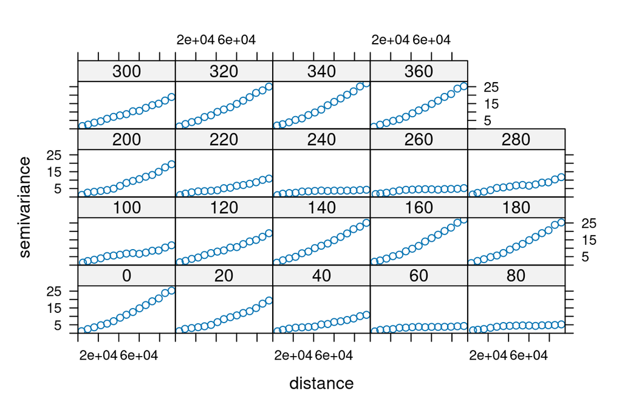

```r
vra <- gstat::variogram(Temp~1, na.omit(smpl.spat), alpha=seq(0,360, 20) )
sp::plot(vra)
```

# Rilassare le condizioni - **stazionarietà**

Trend spaziale: Si introduce un trend deterministico per modellare variazioni sistematiche della media. E.g. Se troviamo delle covariate (e.g. quota che spiega la temperatura) possiamo inserirle nel modello per eliminarne gli effetti ed isolare unicamente l’effetto spaziale separandolo da quello di altre covariate.

Covarianza locale: Si stimano parametri di covarianza diversi per diverse regioni dello spazio.

Decomposizione della varianza: Si scompone la varianza in componenti stazionarie e non stazionarie.

Applicazione di trasformazioni matematiche ai dati per renderli più stazionari (es. logaritmo, potenza).

Modelli geostatistici più complessi che tengano conto della non stazionarietà (Kriging specifico).

Analisi locale: Dividere lo spazio in sottoregioni più omogenee e analizzare separatamente il variogramma in ciascuna sottoregione

# Rilassare le condizioni - **isotropia**

Trasformare le coordinate e.g. Si ruota il sistema di riferimento in modo che gli assi coincidano con le direzioni principali di anisotropia. In questo modo, si può ottenere un variogramma più circolare nelle nuove coordinate.

Utilizzare modelli di variogramma anisotropi più semplici, come quelli con un angolo di rotazione fisso o con un’anisotropia geometrica.

# Variabili regionalizzate

Sono grandezze il cui valore dipende dalla localizzazione ovvero dal vettore delle [X Y] di coordinate spaziali.

La teoria delle variabili regionalizzate non utilizza l’autocorrelazione, ma una proprietà correlata chiamata semivarianza per esprimere il grado di relazione tra i punti di una superficie.

La semivarianza è semplicemente la metà della varianza delle differenze tra tutti i possibili punti distanziati da una distanza costante.

La semivarianza a una distanza d = 0 dovrebbe essere pari a zero, perché non ci sono differenze tra punti che vengono confrontati con se stessi. Tuttavia, man mano che i punti vengono confrontati con punti sempre più distanti, la semivarianza aumenta. A una certa distanza, chiamata intervallo,

la semivarianza diventerà approssimativamente uguale alla varianza della superficie stessa. Si tratta della massima distanza su cui il valore di un punto della superficie è correlato al valore di un altro punto. L’intervallo definisce il massimo vicinato su cui selezionare i punti di controllo per stimare un nodo della griglia, per sfruttare la correlazione statistica tra le osservazioni. Nel caso in cui il nodo della griglia e le osservazioni siano distanziate in modo tale che tutte le distanze superino l’intervallo, il kriging produce la stessa stima della statistica classica, ovvero la media.